# lab_10_sam_zielinski

## Pick a dataset

Pick a dataset (feel free to delete the others from the Rmd file if you would like), and work on the instructions in the next section.

## Instructions

This lab is similar to the last. You’ll pick a dataset and then generate an analysis of that data using data visualizations. The difference here is that instead of a single plot, I would like you to construct 3-4 plots that together tell a linear story. Each plot should be separated by a sentence or two describing what the viewer should take away from the plot. Try to keep the plots similar in some way; perhaps each simply highlights a different subset of the data but has the same underlying layers.

Notice that each of the datasets for today are larger than you will probably be able to use. You will need to filter the data to a particular team, year, subset of curse words. You may further filter the data to highlight an even smaller subset of the data within each plot.

## Analysis

This data shows the amount of curses used in each of Quinten Tarantino’s movies, however is fairly straight forward and not very interesting.

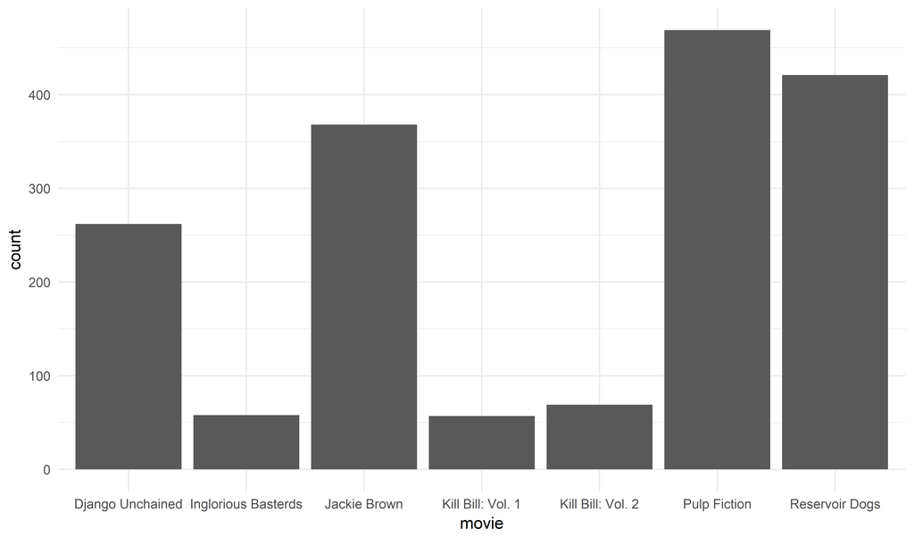

Here, the data is the same as before, but now the bars are colored to show the amount of each curse word used in each film. Unsuprisingly, there is a large number of cursewords, with variations of the same word, and other more creative words that only show up a small handful of times. Overall there is too much data to really make any conclusions from this graph, other than tarantino’s literal rainbow of vulgar language.

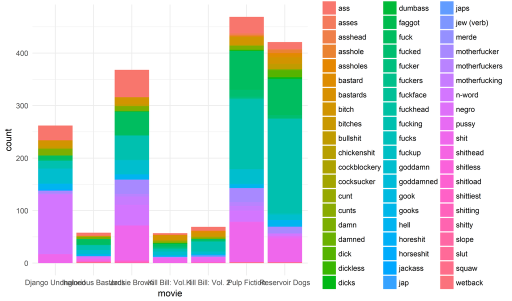

This next graph narrows down the words to only variations of the word fuck. It is not very suprising to see fucking and fuck, the two most basic forms of the word, were the most common. Other variations, such as fuckup and fuckface were less common.

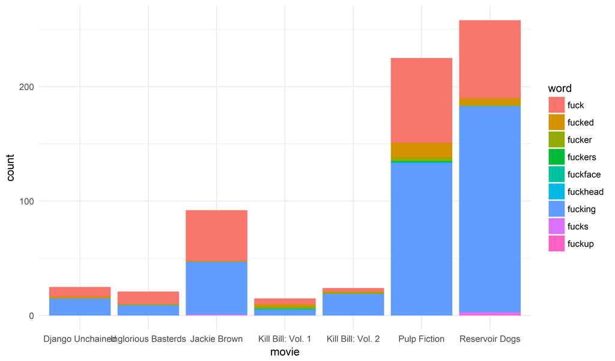

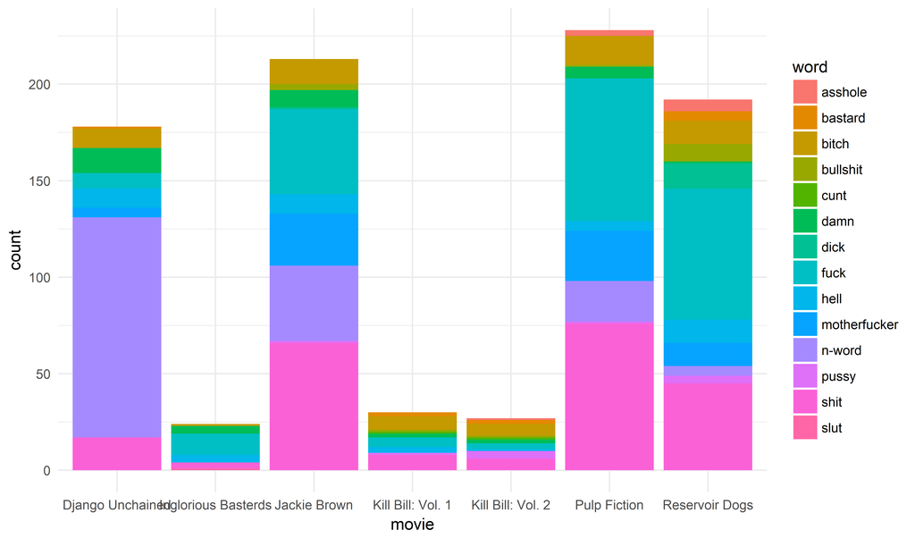

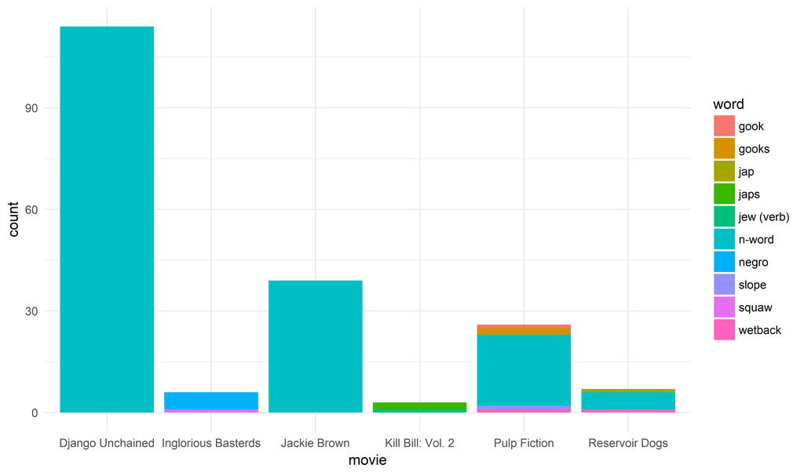